# Data Skills for the Digital World Assignment

Author

Student ID: 2597588

Published

May 10, 2025

# 1. A written summary of the aims of the study.

## 1.1 The aim of the study

In this study, I will investigate the correlation between attractiveness and prestige in UK accents. The motivation for this study is due to my personal experience as an international student studying in the UK. As a native Mandarin Chinese speaker, I have a Chinese accent when speaking English, and this minority accent brought me obstacles when socializing with others. Some people would not be willing to talk to me too much when meeting for the first time after realizing my accent, while they prefer to speak with other Asian students who sound more British or American. Thus, it is likely my less attractive accent is causing this issue. In this case, I would like to research to examine whether there is a strong relationship between attractiveness and prestige in UK accents.

This study will mainly answer three research questions: 1. Is there a strong correlation between an accent’s perceived attractiveness and prestige? 2. Are native English accents more prestigious than non-native English accents? 3. Did the attractiveness and prestige of non-native English accents both increase from 2004 to 2019?

This study will use two datasets: UK accents bishop Coupland and UK accents Sharma et al. These two datasets are provided by my module leader. One was collected by Bishop and Coupland in 2004, and the other was gathered by Sharma and her colleagues in 2019. The former covers 34 and 38 different accents, and most are overlapped in both datasets. I selected these two datasets because they share most of the accents. Since they were collected in 2004 and 2019, there could be changes in the data pattern that are worth analyzing. Moreover, before initiating the research, I read Bishop and Coupland’s journal article (2007). I discovered that Bishop and Coupland researched UK accents’ prestige and attractiveness and emphasized that British society still holds strong stereotypes about accents, but these perceptions are slowly evolving. The role of gender, region, and attitudes toward diversity indicates that language ideologies may be changing over time. Additionally, Sharma et al. (2020) found that attitudes towards British accents remain unchanged from 50 years ago, and Received Pronunciation (RP) is most favored in a professional context. Based on these findings, I will build up my research and visualize the data more vividly and practically.

# 2. Analysis and presentation of the data.

## 2.1 A written description of motivation and methods.

Four graphs—a scatter plot, a bar chart, a pie chart, and a slope graph—were selected for data visualization.

The first research question relates to the correlation between attractiveness and prestige. Based on my previous knowledge, I know that there are four main correlation types: positive linear correlation, negative linear correlation, non-linear correlation, and no correlation. A scatter plot is appropriate to represent the correlation because it allows readers to identify patterns like trends and clusters quickly. The distribution of the dots and the direction of the line of best fit can be easily observed from the plot. I will generally select the ‘Attractiveness’ and ‘Prestige’ columns from the data and set one as my x-value and the other as my y-value. Also, the mean value will be calculated as a comparative parameter to see how many accents are beneath the average and how many are above the average.

The second research question is: Are native English accents more prestigious than non-native English accents? This requires me to compare the Accent Type (Native or Non-native). I will filter non-native accents from native accents and fill them with different colors on the chart. A line chart and a bar chart are available to compare. However, after deliberation, I realized that there is no chronological relation in my data, and the only quantitative value I need is the “Prestige,” which could be my x-value. On the y-axis, I will label the name of each accent. Therefore, a bar chart should be proper. Apart from the bar chart, a pie chart will illustrate the proportion of the accents rated above or below the mean Prestige.

Moving to the third research question: Did the attractiveness and prestige of non-native English accents both increase from 2004 to 2019? Still, a comparison is also required here. However, it differs from the second one as a chronological relation can be found (from 2004 to 2019). Thus, a line chart could be ideal. Nevertheless, after filtering the data, I discovered that there are only five mutual non-native accents from the two datasets, and the gap in the chronological relation is enormous (15 years). To visualize the data more efficiently, I was inspired by Knaflic (2015), who suggested designing a slope graph. We expect the data to be shown as slopes from its name. Indeed, on the x-axis, there will be only two values (2004 and 2019), and there will be ten dots above each year to indicate the value of each non-native accent. Then, the two dots that pair will be connected by a line (e.g., a dot representing the ‘Attractiveness’ of French in 2004 will be linked to that in 2019). Hence, a slope graph is chosen to answer the third research question.

## 2.2 The Scatter Plot

The first research question is: Is there a strong correlation between an accent’s perceived attractiveness and prestige? The scatter plot below will answer this question, and an explanation of the plot will be presented.

```r
# Load the Library
library(here)
library(tidyverse)
library(ggplot2)
```

```r
# Load the data
accent_bc <- read_csv("/Users/vinnyhe/Desktop/R_Language/Vinny's_Data_Skills_Working_Project/datasets/uk_accents_bishop_coupland.csv")
accent_bc
```

| Label | Attractiveness | Prestige | Year |
| --- | --- | --- | --- |
| Accent identical to own | 4.87 | 4.14 | 2004 |
| Afro-Caribbean | 3.72 | 2.90 | 2004 |
| Asian/Indian | 3.21 | 2.74 | 2004 |
| Australian | 4.04 | 3.51 | 2004 |
| Belfast | 3.67 | 3.11 | 2004 |
| Birmingham | 2.92 | 2.70 | 2004 |
| Black Country | 3.16 | 2.81 | 2004 |
| Bristol | 3.64 | 3.22 | 2004 |
| Cardiff | 3.67 | 3.16 | 2004 |
| Cornish | 4.22 | 3.38 | 2004 |

[output cut: 24 more lines]

```r
# Calculate the mean values
avg_x <- mean(accent_bc$Attractiveness, na.rm = TRUE)
avg_y <- mean(accent_bc$Prestige, na.rm = TRUE)

avg_x #3.891471
```

```
[1] 3.891471
```

```r
avg_y #3.466471
```

```
[1] 3.466471
```

```r
# Set quadrants
accent_bc$quadrant <- ifelse(accent_bc$Attractiveness > avg_x & accent_bc$Prestige > avg_y, "I",
                      ifelse(accent_bc$Attractiveness < avg_x & accent_bc$Prestige > avg_y, "II",
                      ifelse(accent_bc$Attractiveness < avg_x & accent_bc$Prestige < avg_y, "III", "IV")))

accent_bc$quadrant <- as.factor(accent_bc$quadrant)
```

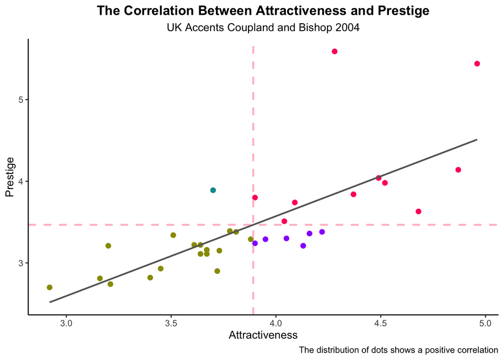

```r
# Scatter plot
ggplot(
  data = accent_bc,
  mapping = aes(x = Attractiveness, y = Prestige, color = quadrant)
) +
  geom_point(size = 2.0) +
  geom_vline(xintercept = avg_x, linetype = "dashed", color = "pink", linewidth = 0.9) +
  geom_hline(yintercept = avg_y, linetype = "dashed", color = "pink", linewidth = 0.9) +
  theme_classic() +
  geom_smooth(method = "lm", se = FALSE, color = "#666666", alpha = 0.5, linewidth = 0.8) +
  labs(x = "Attractiveness", y = "Prestige", subtitle = "UK Accents Coupland and Bishop 2004", , caption = "The distribution of dots shows a positive correlation") +
  ggtitle("The Correlation Between Attractiveness and Prestige") +
  scale_color_manual(values = c("I" = "#FF0066", "II" = "#009999", "III" = "#999900", "IV" = "#9900FF")) +
  theme(legend.position = "none") +
  theme(
    plot.title = element_text(face = "bold", hjust = 0.5), plot.subtitle = element_text(hjust = 0.5))
```

```r
# Count the number of points in each quadrant
quadrant_counts <- accent_bc |>
  mutate(
    Quadrant = case_when(
      Attractiveness >= avg_x & Prestige >= avg_y ~ "Top Right",
      Attractiveness < avg_x & Prestige >= avg_y ~ "Top Left",
      Attractiveness < avg_x & Prestige < avg_y ~ "Bottom Left",
      Attractiveness >= avg_x & Prestige < avg_y ~ "Bottom Right"
    )
  ) |>
  count(Quadrant)
quadrant_counts
```

| Quadrant | n |
| --- | --- |
| Bottom Left | 17 |
| Bottom Right | 6 |
| Top Left | 1 |
| Top Right | 10 |

#### **Plot Description:**

This scatter plot divides accents into four quadrants based on their attractiveness and prestige scores. Accents in the top-right quadrant are highly rated on both dimensions (e.g., RP and Scottish), while those in the bottom-left (e.g., Asian/Indian) are rated poorly. This helps identify how prestige and attractiveness align. The dots illustrate a positive correlation: as the level of attractiveness increases, prestige also rises. The horizontal and vertical lines divide the plot into four quadrants, with the dots colored differently in each quadrant. There are 10 dots in Quadrant I, one in Quadrant II, 17 in Quadrant III, and six in Quadrant IV. I did this because it is easier for readers to visualize the distribution of dots in each quadrant. The distribution pattern could also inspire a new study on why most dots cluster in Quadrants I and III.

## 2.3 The Bar Chart and Pie Chart

The bar chart below will answer the second research question: Are native English accents more prestigious than non-native English accents? In addition, a pie chart will indicate the proportion of the accents rated above or below the mean (3.466).

```r
# Load the Data
accent_bc <- read_csv("/Users/vinnyhe/Desktop/R_Language/Vinny's_Data_Skills_Working_Project/datasets/uk_accents_bishop_coupland.csv")
accent_bc
```

| Label | Attractiveness | Prestige | Year |
| --- | --- | --- | --- |
| Accent identical to own | 4.87 | 4.14 | 2004 |
| Afro-Caribbean | 3.72 | 2.90 | 2004 |
| Asian/Indian | 3.21 | 2.74 | 2004 |
| Australian | 4.04 | 3.51 | 2004 |
| Belfast | 3.67 | 3.11 | 2004 |
| Birmingham | 2.92 | 2.70 | 2004 |
| Black Country | 3.16 | 2.81 | 2004 |
| Bristol | 3.64 | 3.22 | 2004 |
| Cardiff | 3.67 | 3.16 | 2004 |
| Cornish | 4.22 | 3.38 | 2004 |

[output cut: 24 more lines]

```r
# Non-native Accents
non_native_bc <- data.frame (
  Region = c("Afro-Caribbean", "Asian/Indian", "French", "German", "Spanish"),
  Attractiveness = c(3.72, 3.21, 4.09, 3.2, 3.88),
  Prestige = c(2.9, 2.74, 3.74, 3.21, 3.29)
)
non_native_bc
```

| Region | Attractiveness | Prestige |
| --- | --- | --- |
| Afro-Caribbean | 3.72 | 2.90 |
| Asian/Indian | 3.21 | 2.74 |
| French | 4.09 | 3.74 |
| German | 3.20 | 3.21 |
| Spanish | 3.88 | 3.29 |

```r
# Re-Label the data frame
new_accent_bc <- accent_bc |>
  mutate(Accent_Type = ifelse(Label %in% non_native_bc$Region, "Non-Native", "Native")) |>
  mutate(Accent_Type = as.factor(Accent_Type))
new_accent_bc
```

| Label | Attractiveness | Prestige | Year | Accent_Type |
| --- | --- | --- | --- | --- |
| Accent identical to own | 4.87 | 4.14 | 2004 | Native |
| Afro-Caribbean | 3.72 | 2.90 | 2004 | Non-Native |
| Asian/Indian | 3.21 | 2.74 | 2004 | Non-Native |
| Australian | 4.04 | 3.51 | 2004 | Native |
| Belfast | 3.67 | 3.11 | 2004 | Native |
| Birmingham | 2.92 | 2.70 | 2004 | Native |
| Black Country | 3.16 | 2.81 | 2004 | Native |
| Bristol | 3.64 | 3.22 | 2004 | Native |
| Cardiff | 3.67 | 3.16 | 2004 | Native |
| Cornish | 4.22 | 3.38 | 2004 | Native |

[output cut: 24 more lines]

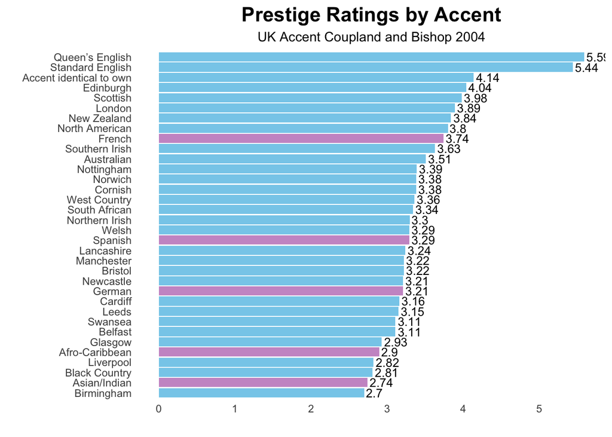

```r
# Bar Chart
ggplot(
  data = new_accent_bc,
  mapping = aes(x = reorder(Label, Prestige, increasing = TRUE), y = Prestige, fill = Accent_Type, x_nudge = -10)) +
  geom_text(aes(label = round(Prestige, 3)), hjust = - 0.1, size = 3.5) +
  geom_col() +
  coord_flip() +
  theme_classic() +
  labs(x = " ", y = " ", title = "Prestige Ratings by Accent",
       subtitle = "UK Accent Coupland and Bishop 2004") +
  theme(legend.position = "none",
        axis.line.y = element_blank(), axis.line.x = element_blank(), axis.ticks = element_blank()) +
  scale_fill_manual(values = c("skyblue", "#CC99CC")) +
  scale_y_continuous(breaks = seq(0, 5, by = 1)) +
  theme(
    plot.title = element_text(size = 16.5, face = "bold", hjust = 0.5), plot.subtitle = element_text(hjust = 0.5))
```

```r
# Native Accent_BC
native_bc <- new_accent_bc |>
  filter(Accent_Type == "Native")
native_bc
```

| Label | Attractiveness | Prestige | Year | Accent_Type |
| --- | --- | --- | --- | --- |
| Accent identical to own | 4.87 | 4.14 | 2004 | Native |
| Australian | 4.04 | 3.51 | 2004 | Native |
| Belfast | 3.67 | 3.11 | 2004 | Native |
| Birmingham | 2.92 | 2.70 | 2004 | Native |
| Black Country | 3.16 | 2.81 | 2004 | Native |
| Bristol | 3.64 | 3.22 | 2004 | Native |
| Cardiff | 3.67 | 3.16 | 2004 | Native |
| Cornish | 4.22 | 3.38 | 2004 | Native |
| Edinburgh | 4.49 | 4.04 | 2004 | Native |
| Glasgow | 3.45 | 2.93 | 2004 | Native |

[output cut: 19 more lines]

```r
# Count Prestige Rating > 3.74 (French Accent)
prestige_bigger_than_3.74 <- native_bc |>
  count(Prestige > 3.74)
prestige_bigger_than_3.74
```

| Prestige > 3.74 | n |
| --- | --- |
| FALSE | 21 |
| TRUE | 8 |

```r
# Count Prestige Rating > 3.29 (Spanish Accent)
prestige_bigger_than_3.29 <- native_bc |>
  count(Prestige > 3.29)
prestige_bigger_than_3.29
```

| Prestige > 3.29 | n |
| --- | --- |
| FALSE | 13 |
| TRUE | 16 |

```r
# Count Prestige Rating > 3.21 (German Accent)
prestige_bigger_than_3.21 <- native_bc |>
  count(Prestige > 3.21)
prestige_bigger_than_3.21
```

| Prestige > 3.21 | n |
| --- | --- |
| FALSE | 9 |
| TRUE | 20 |

```r
# Count Prestige < 2.9 (Afro-Caribbean)
prestige_smaller_than_2.9 <- native_bc |>
  count(Prestige < 2.9)
prestige_smaller_than_2.9
```

| Prestige < 2.9 | n |
| --- | --- |
| FALSE | 26 |
| TRUE | 3 |

```r
# Select Label and Prestige
attrac_bc <- accent_bc |>
  select(Label, Prestige)
```

```r
# Define the mean value
mean_prestige <- 3.466
```

```r
# Label Prestige as "Bigger than Mean" or "Smaller than Mean"
relabel_bc <- attrac_bc |>
  mutate(Comparison_with_the_Mean = ifelse(Prestige > mean_prestige,
                                         "Bigger than Mean",
                                           "Smaller than Mean")) |>
  mutate(Comparison_with_the_Mean = as.factor(Comparison_with_the_Mean))
relabel_bc
```

| Label | Prestige | Comparison_with_the_Mean |
| --- | --- | --- |
| Accent identical to own | 4.14 | Bigger than Mean |
| Afro-Caribbean | 2.90 | Smaller than Mean |
| Asian/Indian | 2.74 | Smaller than Mean |
| Australian | 3.51 | Bigger than Mean |
| Belfast | 3.11 | Smaller than Mean |
| Birmingham | 2.70 | Smaller than Mean |
| Black Country | 2.81 | Smaller than Mean |
| Bristol | 3.22 | Smaller than Mean |
| Cardiff | 3.16 | Smaller than Mean |
| Cornish | 3.38 | Smaller than Mean |

[output cut: 24 more lines]

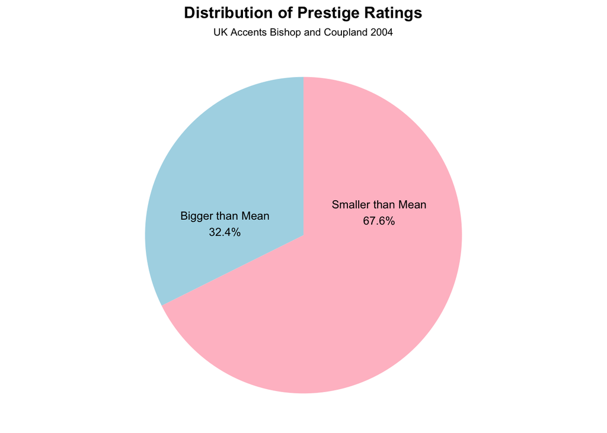

```r
# Pie chart
pie_bc <- relabel_bc |>
  count(Comparison_with_the_Mean)
ggplot(pie_bc, aes(x = " ", y = n, fill = Comparison_with_the_Mean)) +
  geom_bar(stat = "identity", width = 1) +
  coord_polar(theta = "y") +
  theme_classic() +
  theme_void() +
  scale_fill_manual(values = c("Bigger than Mean" = "lightblue", "Smaller than Mean" = "pink")) +
  geom_text(
    aes(
      label = paste0(Comparison_with_the_Mean, "\n", scales::percent(n / sum(n), accuracy = 0.1))
    ),
    position = position_stack(vjust = 0.3),
    size = 3.3,
    color = "black"
  ) +
  labs(title = "Distribution of Prestige Ratings",
       subtitle = "UK Accents Bishop and Coupland 2004") +
  theme(legend.position = " ") +
  theme(
    plot.title = element_text(face = "bold", hjust = 0.5), plot.subtitle = element_text(size = 8.5, hjust = 0.5))
```

#### **Pie Chart Description:**

This pie chart categorises accents into those rated above or below the mean prestige score. It provides a quick visual summary of the number of accents perceived as prestigious. The pie chart reveals that only 32.4% of the accents’ Prestige is above the mean value, and 67.6% is below the mean. Since more accents are rated below the mean, this might suggest a prestige bias, where only a few are considered highly prestigious. Also, I consulted ChatGPT to calculate the percentage of accents and how to label the percentage with text on the chart.

## 2.4 The Slope Graph

This slope graph will investigate whether the attractiveness and prestige of non-native English accents both increased from 2004 to 2019.

```r
# Load the Library
library(wesanderson)
```

```r
# Load the Data
accent_bc <- read_csv("/Users/vinnyhe/Desktop/R_Language/Vinny's_Data_Skills_Working_Project/datasets/uk_accents_bishop_coupland.csv")
accent_bc
```

| Label | Attractiveness | Prestige | Year |
| --- | --- | --- | --- |
| Accent identical to own | 4.87 | 4.14 | 2004 |
| Afro-Caribbean | 3.72 | 2.90 | 2004 |
| Asian/Indian | 3.21 | 2.74 | 2004 |
| Australian | 4.04 | 3.51 | 2004 |
| Belfast | 3.67 | 3.11 | 2004 |
| Birmingham | 2.92 | 2.70 | 2004 |
| Black Country | 3.16 | 2.81 | 2004 |
| Bristol | 3.64 | 3.22 | 2004 |
| Cardiff | 3.67 | 3.16 | 2004 |
| Cornish | 4.22 | 3.38 | 2004 |

[output cut: 24 more lines]

```r
accent_sha <- read_csv("/Users/vinnyhe/Desktop/R_Language/Vinny's_Data_Skills_Working_Project/datasets/uk_accents_sharma_et_al.csv")
accent_sha
```

| Label | Attractiveness | Prestige | Year |
| --- | --- | --- | --- |
| Accent identical to own | 4.54 | 4.37 | 2019 |
| Afro-Caribbean | 4.02 | 3.52 | 2019 |
| Asian/Indian | 3.54 | 3.38 | 2019 |
| Australian | 4.44 | 4.17 | 2019 |
| Belfast | 3.87 | 3.63 | 2019 |
| Birmingham | 3.30 | 3.20 | 2019 |
| Black Country | 3.56 | 3.39 | 2019 |
| Bristol | 3.96 | 3.81 | 2019 |
| Cardiff | 4.10 | 3.85 | 2019 |
| Chinese | 3.50 | 3.56 | 2019 |

[output cut: 28 more lines]

```r
# Non-native Accents Bishop
non_native_bc <- data.frame (
  Region = c("Afro-Caribbean", "Asian/Indian", "French", "German", "Spanish"),
  Attractiveness = c(3.72, 3.21, 4.09, 3.2, 3.88),
  Prestige = c(2.9, 2.74, 3.74, 3.21, 3.29)
)
non_native_bc
```

| Region | Attractiveness | Prestige |
| --- | --- | --- |
| Afro-Caribbean | 3.72 | 2.90 |
| Asian/Indian | 3.21 | 2.74 |
| French | 4.09 | 3.74 |
| German | 3.20 | 3.21 |
| Spanish | 3.88 | 3.29 |

```r
accent_bc <- accent_bc |>
  mutate(Accent_Type = ifelse(Label %in% non_native_bc$Region, "Non-Native", "Native")) |>
  mutate(Accent_Type = as.factor(Accent_Type))
accent_bc
```

| Label | Attractiveness | Prestige | Year | Accent_Type |
| --- | --- | --- | --- | --- |
| Accent identical to own | 4.87 | 4.14 | 2004 | Native |
| Afro-Caribbean | 3.72 | 2.90 | 2004 | Non-Native |
| Asian/Indian | 3.21 | 2.74 | 2004 | Non-Native |
| Australian | 4.04 | 3.51 | 2004 | Native |
| Belfast | 3.67 | 3.11 | 2004 | Native |
| Birmingham | 2.92 | 2.70 | 2004 | Native |
| Black Country | 3.16 | 2.81 | 2004 | Native |
| Bristol | 3.64 | 3.22 | 2004 | Native |
| Cardiff | 3.67 | 3.16 | 2004 | Native |
| Cornish | 4.22 | 3.38 | 2004 | Native |

[output cut: 24 more lines]

```r
# Non-native Accents Sharma
non_native_sha <- data.frame(
  Region = c("Afro-Caribbean", "Asian/Indian","Chinese", "French", "German", "MLE", "Spanish"),
  Attractiveness = c(4.02, 3.54, 3.5, 4.57, 3.77, 3.89, 4.42),
  Prestige = c(3.52, 3.38, 3.56, 4.56, 3.88, 3.81, 4.09)
)
non_native_sha
```

| Region | Attractiveness | Prestige |
| --- | --- | --- |
| Afro-Caribbean | 4.02 | 3.52 |
| Asian/Indian | 3.54 | 3.38 |
| Chinese | 3.50 | 3.56 |
| French | 4.57 | 4.56 |
| German | 3.77 | 3.88 |
| MLE | 3.89 | 3.81 |
| Spanish | 4.42 | 4.09 |

```r
# Mutual Non-native Accent
mutual_non_native_accent <- data.frame (
  Region = c("Afro-Caribbean", "Asian/Indian", "French", "German", "Spanish"),
  Attrac_2019 = c(4.02, 3.54, 4.57, 3.77, 4.42),
  Pres_2019 = c(3.52, 3.38, 4.56, 3.88, 4.09),
  Attrac_2004 = c(3.72, 3.21, 4.09, 3.2, 3.88),
  Pres_2004 = c(2.9, 2.74, 3.74, 3.21, 3.29)
)
mutual_non_native_accent
```

| Region | Attrac_2019 | Pres_2019 | Attrac_2004 | Pres_2004 |
| --- | --- | --- | --- | --- |
| Afro-Caribbean | 4.02 | 3.52 | 3.72 | 2.90 |
| Asian/Indian | 3.54 | 3.38 | 3.21 | 2.74 |
| French | 4.57 | 4.56 | 4.09 | 3.74 |
| German | 3.77 | 3.88 | 3.20 | 3.21 |
| Spanish | 4.42 | 4.09 | 3.88 | 3.29 |

```r
# Pivot Data
mutual_long <- mutual_non_native_accent |>
  pivot_longer(cols = c(Attrac_2019, Attrac_2004, Pres_2019, Pres_2004),
               names_to = "Type",
               values_to = "AttracPres") |>
  mutate(Year = ifelse(grepl("2019", Type), 2019, 2004),
         Type = ifelse(grepl("Attrac", Type), "Attractiveness", "Prestige"))
mutual_long
```

| Region | Type | AttracPres | Year |
| --- | --- | --- | --- |
| Afro-Caribbean | Attractiveness | 4.02 | 2019 |
| Afro-Caribbean | Attractiveness | 3.72 | 2004 |
| Afro-Caribbean | Prestige | 3.52 | 2019 |
| Afro-Caribbean | Prestige | 2.90 | 2004 |
| Asian/Indian | Attractiveness | 3.54 | 2019 |
| Asian/Indian | Attractiveness | 3.21 | 2004 |
| Asian/Indian | Prestige | 3.38 | 2019 |
| Asian/Indian | Prestige | 2.74 | 2004 |
| French | Attractiveness | 4.57 | 2019 |
| French | Attractiveness | 4.09 | 2004 |

[output cut: 10 more lines]

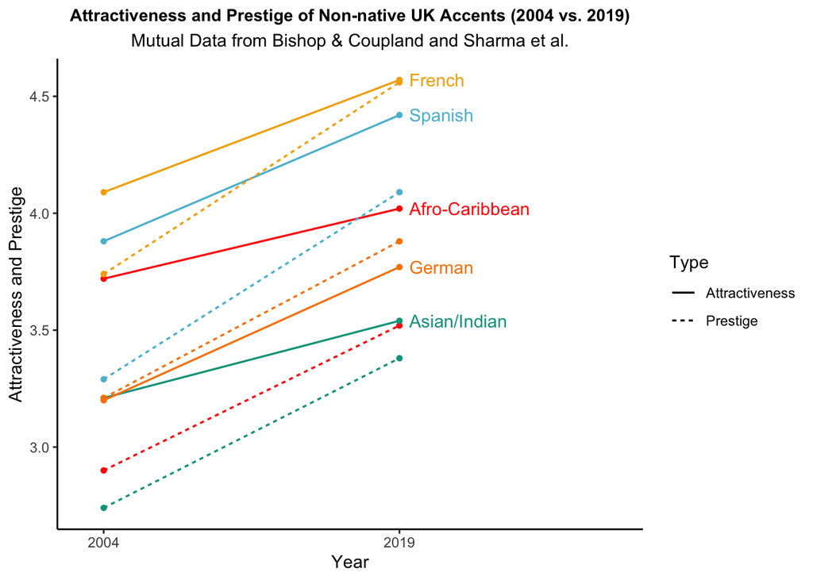

```r
# Slope Graph
ggplot(data = mutual_long,
       mapping = aes(x = Year, y = AttracPres, group = interaction(Region, Type),
                     color = Region, linetype = Type)) +
  geom_point(size = 1.2) +
  geom_line(linewidth = 0.6) +
  scale_x_continuous(breaks = c(2004, 2019), limits = c(2003, 2030)) +
  geom_text(data = mutual_long |> filter(Year == 2019, Type == "Attractiveness"), aes(label = Region), hjust = 0, nudge_x = 0.5) +
 scale_color_manual(values = wes_palette(n = 5, name = "Darjeeling1")) +
  theme_classic() +
  theme(legend.position = "right") +
  guides(color = "none") +
  labs(title = "Attractiveness and Prestige of Non-native UK Accents (2004 vs. 2019)",
       subtitle = "Mutual Data from Bishop & Coupland and Sharma et al.",
       x = "Year", y = "Attractiveness and Prestige") +
  theme(
    plot.title = element_text(size = 10.5, face = "bold", hjust = 0.5), plot.subtitle = element_text(hjust = 0.5))
```

```r
# Calculate the Slope
mutual_non_native_accent$Slope_Attrac <- (mutual_non_native_accent$Attrac_2019 - mutual_non_native_accent$Attrac_2004) / 15
mutual_non_native_accent$Slope_Pres <- (mutual_non_native_accent$Pres_2019 - mutual_non_native_accent$Pres_2004) / 15

mutual_non_native_accent
```

| Region | Attrac_2019 | Pres_2019 | Attrac_2004 | Pres_2004 | Slope_Attrac | Slope_Pres |
| --- | --- | --- | --- | --- | --- | --- |
| Afro-Caribbean | 4.02 | 3.52 | 3.72 | 2.90 | 0.020 | 0.04133333 |
| Asian/Indian | 3.54 | 3.38 | 3.21 | 2.74 | 0.022 | 0.04266667 |
| French | 4.57 | 4.56 | 4.09 | 3.74 | 0.032 | 0.05466667 |
| German | 3.77 | 3.88 | 3.20 | 3.21 | 0.038 | 0.04466667 |
| Spanish | 4.42 | 4.09 | 3.88 | 3.29 | 0.036 | 0.05333333 |